# 個人プロジェクト(仮)

井原沙耶

2021/12/17

## 1.はじめに

1.なぜこのテーマを取り上げたのか

- 先進国は北半球に集中し、貧困国は南半球に集中しているという事実を知り、どのような因果関係があるのか疑問に思っていた。ある講義で「貧困と気温は相関がある」という意見が出たため、実際に相関があるのかどうか調べるためにこのテーマを取り上げた。

## 2.仮説

#### 「貧困国が南半球に集中しているのには、気温が関係している」

## 3.問題の背景

### 貧困とは、1 日 1.90ドル未満で暮らす人のことを指す

#### 世界

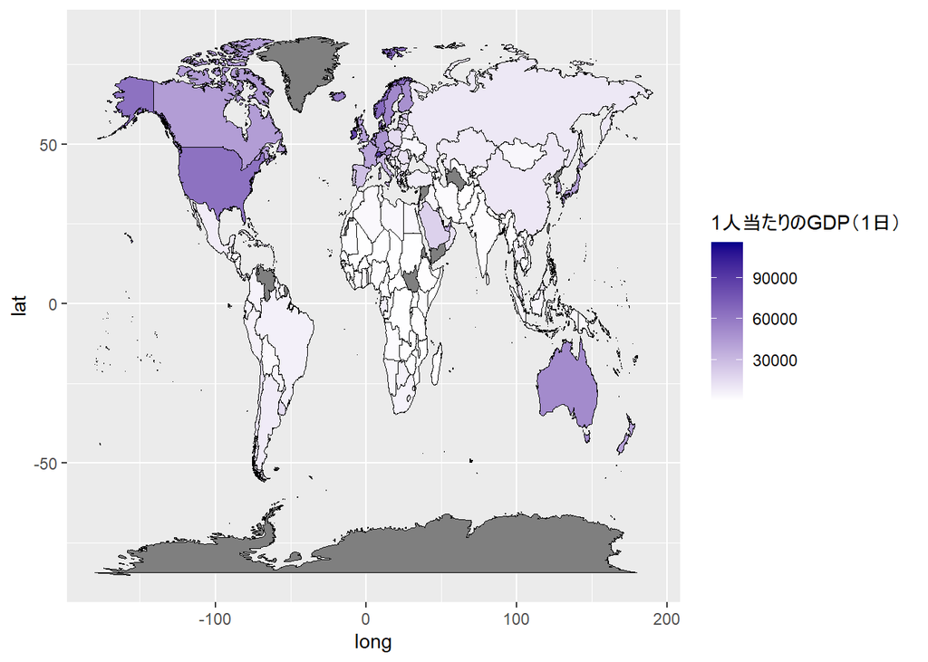

```r
world <- map_data("world")

#1人当たりのGDP/360
dat = WDI(indicator='NY.GDP.PCAP.CD',
          start=2020, end=2020)

world <- world %>%
  mutate(iso2c = countrycode(sourcevar = region, origin = "country.name", destination = "iso2c"))

left_join(world, dat, by ="iso2c") %>%
  ggplot() +
  geom_polygon(aes(x = long, y = lat, group = group, fill =NY.GDP.PCAP.CD ),
               colour = "black", size = 0.1) +
  scale_fill_continuous(name = "1人当たりのGDP（1日） ", low = "white", high = "darkblue")
```

上の図から裕福な国（紫）の多くは北半球に位置し、貧困国（白）は赤道付近や南半球に集中していることがわかる

## 4.分析

### 4-1データ紹介

- THE WORLD BANK-GDP per capita (https://data.worldbank.org/indicator/NY.GDP.PCAP.CD)
- 総務省統計局-世界の統計2021(https://www.stat.go.jp/data/sekai/0116.html#header)

#### 記述統計

- 平均($) 23629
- 中央値($) 14243
- 最大値($) 87097
- 最小値($) 936
- 標準偏差($) 22525
- ヒストグラム

```r
temperature<-read_excel("01.xlsx",skip=3,sheet=5)
```

```
## * `` -> ...5
## * `` -> ...8
## * `` -> ...10
## * `` -> ...12
## * `` -> ...13
```

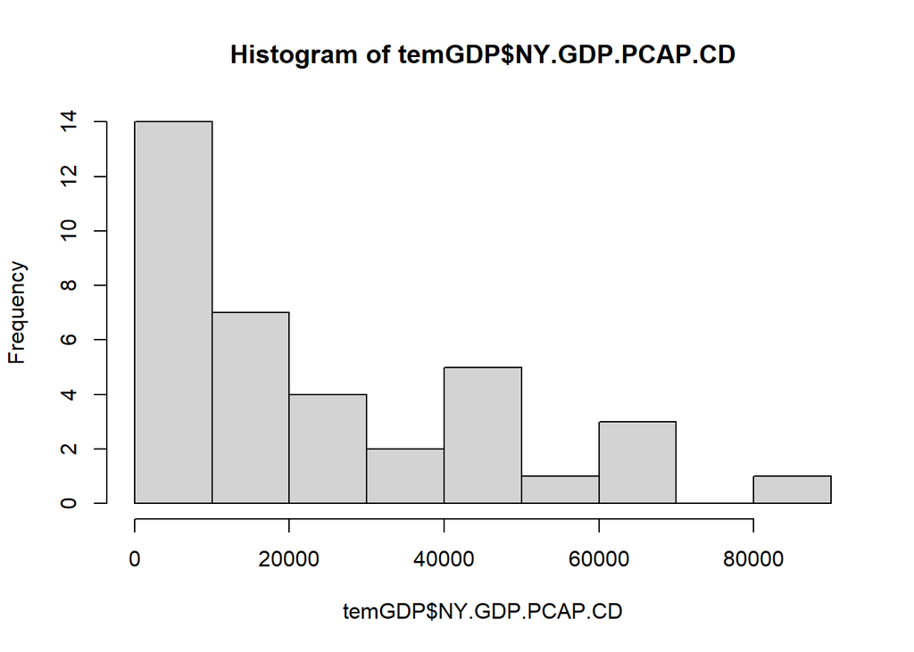

```r
temGDP <-left_join(temperature, dat, by ="iso2c")
hist(temGDP$NY.GDP.PCAP.CD)
```

### 4-2分析方法

```r
temperature<-read_excel("01.xlsx",skip=3,sheet=5)
```

```
## * `` -> ...5
## * `` -> ...8
## * `` -> ...10
## * `` -> ...12
## * `` -> ...13
```

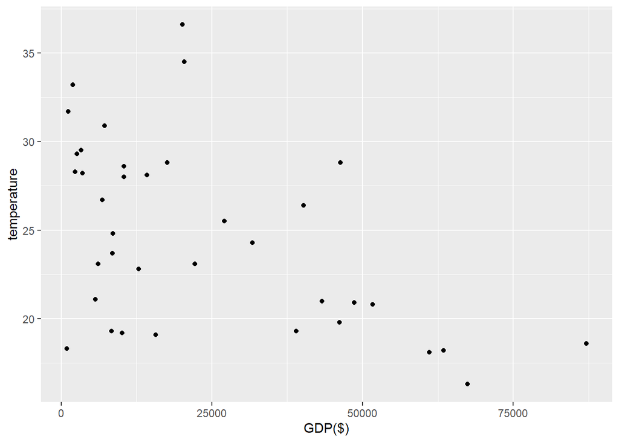

```r
temGDP <-left_join(temperature, dat, by ="iso2c")

temGDP %>%
  ggplot()+
  geom_point(aes(x=NY.GDP.PCAP.CD,y=high))+
  xlab("GDP($)")+ylab("temperature")
```

```r
temperature<-read_excel("01.xlsx",skip=3,sheet=5)
```

```
## * `` -> ...5
## * `` -> ...8
## * `` -> ...10
## * `` -> ...12
## * `` -> ...13
```

```r
temGDP <-left_join(temperature, dat, by ="iso2c")
temGDP %>%
  select(NY.GDP.PCAP.CD,high)->temGDPsmall

library(psych)
```

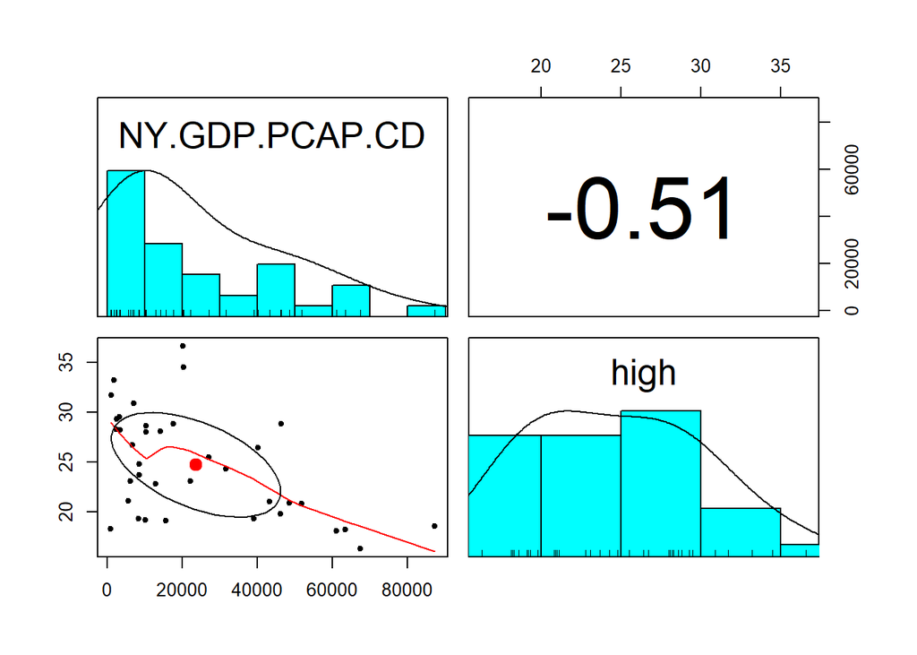

```r
pairs.panels(temGDPsmall)
```